# Exercises, Part II

M Loecher

## ROC curves, revisited

Using AUC (“area under the curve”) as a metric, compare the classification accuracy of the following model, w.r.t. the Titanic data:

1. logistic regression
2. Classification tree from *rpart*
3. Classification tree from *partykit*

```
## working on glm
## working on rpart
## working on party
```

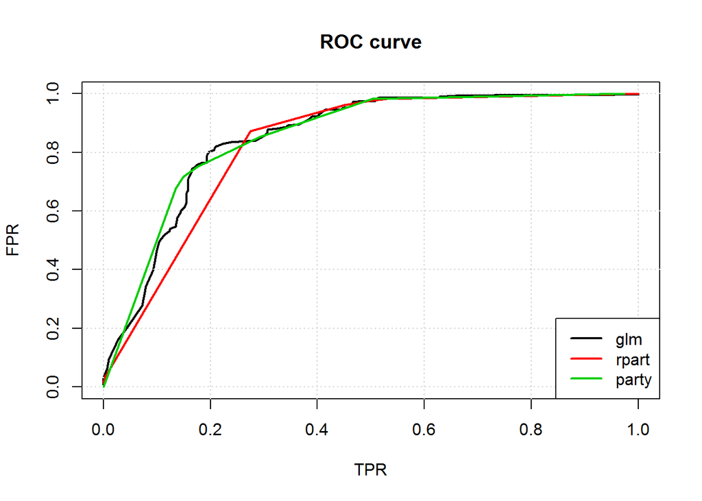

## Understanding Trees

1. Sketch the tree corresponding to the partition of the predictor space illustrated in the left-hand panel of the Figure below. The numbers inside the boxes indicate the mean of $Y$ within each region.

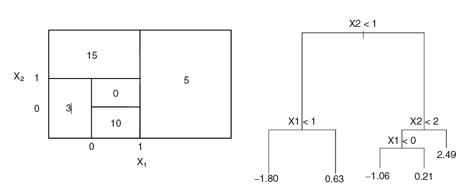

Tree Partition

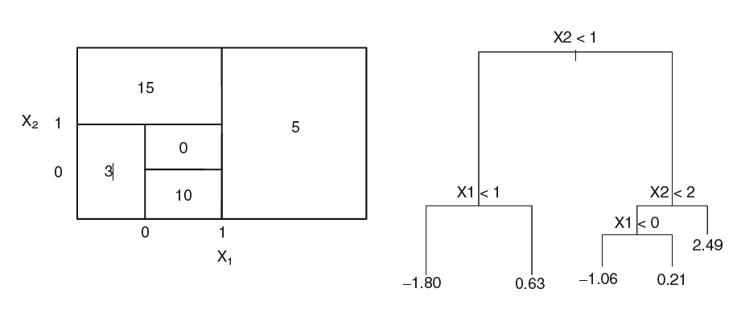

```r
knitr::include_graphics("figures/Fig8.12.png")
```

2. Create a diagram similar to the left-hand panel of the Figure, using the tree illustrated in the right-hand panel of the same figure. You should divide up the predictor space into the correct regions, and indicate the mean for each region.

Solution

*If $X_1 \ge 1$ then 5, else if $X_2 \ge 1$ then 15, else if $X_1 < 0$ then 3, else if $X_2 <0$ then 10, else 0.*

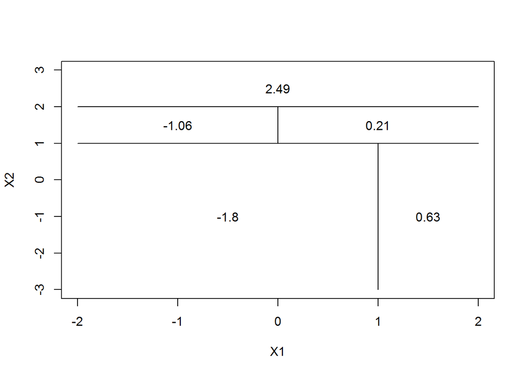

```r
par(xpd = NA)
plot(NA, NA, type = "n", xlim = c(-2, 2), ylim = c(-3, 3), xlab = "X1", ylab = "X2")
# X2 < 1
lines(x = c(-2, 2), y = c(1, 1))
# X1 < 1 with X2 < 1
lines(x = c(1, 1), y = c(-3, 1))
text(x = (-2 + 1)/2, y = -1, labels = c(-1.8))
text(x = 1.5, y = -1, labels = c(0.63))
# X2 < 2 with X2 >= 1
lines(x = c(-2, 2), y = c(2, 2))
text(x = 0, y = 2.5, labels = c(2.49))
# X1 < 0 with X2<2 and X2>=1
lines(x = c(0, 0), y = c(1, 2))
text(x = -1, y = 1.5, labels = c(-1.06))
text(x = 1, y = 1.5, labels = c(0.21))
```

## Bagging

Write your own code that averages 100 bootstrapped trees and evaluate the results for the Boston data.

## Random Forests

Fit a few random forests to the “Boston” data using a variety of values for the “mtry” and “ntree” parameters. Create a plot displaying the test error resulting from random forests on this data set for a more comprehensive range of values for “mtry” and “ntree”. Describe the results obtained.

Solution

```r
library(MASS)
library(randomForest)
set.seed(1)
train <- sample(1:nrow(Boston), nrow(Boston) / 2)
Boston.train <- Boston[train, -14]
Boston.test <- Boston[-train, -14]
Y.train <- Boston[train, 14]
Y.test <- Boston[-train, 14]
rf.boston1 <- randomForest(Boston.train, y = Y.train, xtest = Boston.test, ytest = Y.test, mtry = ncol(Boston) - 1, ntree = 500)
rf.boston2 <- randomForest(Boston.train, y = Y.train, xtest = Boston.test, ytest = Y.test, mtry = (ncol(Boston) - 1) / 2, ntree = 500)
rf.boston3 <- randomForest(Boston.train, y = Y.train, xtest = Boston.test, ytest = Y.test, mtry = sqrt(ncol(Boston) - 1), ntree = 500)
plot(1:500, rf.boston1$test$mse, col = "green", type = "l", xlab = "Number of Trees", ylab = "Test MSE", ylim = c(10, 19))
lines(1:500, rf.boston2$test$mse, col = "red", type = "l")
lines(1:500, rf.boston3$test$mse, col = "blue", type = "l")
legend("topright", c("m = p", "m = p/2", "m = sqrt(p)"), col = c("green", "red", "blue"), cex = 1, lty = 1)
```

[output not shown]